# tarea6

$$\textbf{Reconocimiento estadístico de Patrones. Tarea 6}$$ $$\textit{Y. Sarahi García Gozález}$$

```python
import numpy as np
import matplotlib.pyplot as plt
import pandas as pd
from sklearn import tree
from sklearn.tree import DecisionTreeClassifier
from sklearn.model_selection import cross_val_score,train_test_split
from sklearn.metrics import accuracy_score,confusion_matrix, classification_report, ConfusionMatrixDisplay
from sklearn.linear_model import LogisticRegression
from sklearn.svm import SVC
from scipy.stats import multivariate_normal
```

$\color{lightblue}{Ejericicio \space 2}$

$$Y\sim Bern(0.5)$$ $$X|Y=0\sim N((0,0),A)$$ $$X|Y=1\sim N((1,2),A)$$

$\begin{equation} A= \begin{pmatrix} 1 & 0.4\\ 0.4 & 1 \end{pmatrix} \end{equation}$

a)

Partimos de:

$$ \min E_{Y \mid X=x} L(Y(x), \hat{Y}(x)) $$

Con función de consto $L(0,1)=L(1,0)=c$, $c$ una constante.

Por tratarse de una clasificación binario, sabemos que la solución es: $$ \hat{Y}(x)=I\left(\frac{P(X=x \mid Y=1)}{P(X=x \mid Y=0)}>\frac{L(0,1) P(Y=0)}{L(1,0) P(Y=1)}\right) $$

Para nuestro problema tenemos:

- $$P(X=x \mid Y=1)= \frac{1}{(2 \pi)|A|^{\frac{1}{2}}} \exp \left(-\frac{1}{2}(x-(1,2))^{\top} A^{-1}(x-(1,2))\right)$$
- $$P(X=x \mid Y=0)=\frac{1}{(2 \pi)|A|^{\frac{1}{2}}} \exp \left(-\frac{1}{2}(x-(0,0))^{\top} A^{-1}(x-(0,0))\right)$$
- $$ P(Y=1)= P(Y=0)=0.5$$

Sustituyendo: $$ \hat{Y}(x)=I\left(\frac{\exp \left(-\frac{1}{2}\left(x-(1,2)^{\top}\right)^{\top} A^{-1}\left(x-(1,2)^{\top}\right)\right)}{\exp \left(-\frac{1}{2}\left(x-(0,0)^{\top}\right)^{\top} A^{-1}\left(x-(0,0)^{\top}\right)\right)}>1\right) $$

$$ \implies \hat{Y}(x)=I\left(\exp \left(-\frac{1}{2}\left(x-(1,2)^{\top}\right)^{\top} A^{-1}\left(x-(1,2)^{\top}\right)+\frac{1}{2}\left(x-(0,0)^{\top}\right)^{\top} A^{-1}\left(x-(0,0)^{\top}\right)\right)>1\right) $$

Aplicando logaritmo natural tenemos: $$ \hat{Y}(x)=I\left(-\frac{1}{2}\left[\left(x-(1,2)^{\top}\right)^{\top} A^{-1}\left(x-(1,2)^{\top}\right)-\left(x-(0,0)^{\top}\right)^{\top} A^{-1}\left(x-(0,0)^{\top}\right)\right]>ln(1)\right) $$

b)

```python
# Función para generar muestras de X|Y
def muestras(n, A):
    #Y tiene distribución de Bernoulli con theta=0.5
    Y = np.random.choice([0, 1], size=n, p=[0.5, 0.5])
    #Inicializamos X en ceros
    X = np.zeros((n, 2))

    #Generamos X|Y usando la normal bivariada con cov=A y mu=(0,0) si Y=0 y mu=(1,2) si Y=1
    for i in range(n):
        if Y[i] == 0:
            X[i] = np.random.multivariate_normal([0, 0], A)
        else:
            X[i] = np.random.multivariate_normal([1, 2], A)

    return X, Y
```

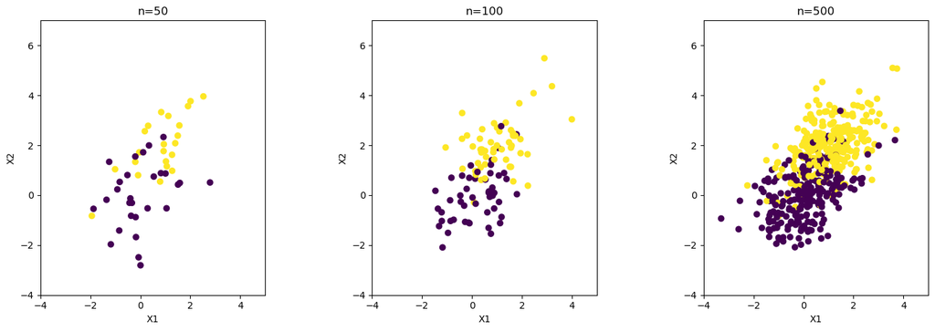

```python
#Definimos A
A = np.array([[1, 0.4], [0.4, 1]])
#Graficamos las muestras
n = [50, 100, 500]
fig, axs = plt.subplots(1, 3, figsize=(15, 5))

for i, n in enumerate(n):
    X, Y = muestras(n, A)
    axs[i].scatter(X[:, 0], X[:, 1], c=Y, cmap='viridis')
    axs[i].set_xlabel('X1')
    axs[i].set_ylabel('X2')
    axs[i].set_title(f'n={n}')
    axs[i].set_aspect('equal')
    axs[i].set_xlim(-4, 5)
    axs[i].set_ylim(-4, 7)

plt.tight_layout()
plt.show()
```

c)

En este inciso para cada $n \in [50,100,500]$:

```
1. Se divide el conjunto total en Train y Test

2. Se ajusta un árbol de desición (unpruned)
    (se hace la predicción sobre el conjunto test y se muestra la frontera de desición, el acurracy, el classification_report, la matriz de confusión, el árbol COMPLETO y la profundidad de éste)

3. Se hace la validación cruzada para distintas profundidades
    (se toman un número de profundidades distintas para cada $n$ en función de la profuncidad del árbol completo (unpruned))

4. Se compara el mejor modelo con el clasificador Bayessiano óptimo
    (De manera cuantitativa con el accuracy y el classification_report y de manera visual con la gráfica de frontera de desición)
```

Al final se encuentran las conclusiones

```python
def plot_decision_boundary(clf, X, Y, title):
    '''
    Se grafican las fronteras de desición de acuerdo con el clasificador clf
    Se grafican las muestras X,Y sobre las que se hará la desición (conjunto test)
    '''
    x_min, x_max = X[:, 0].min() - 1, X[:, 0].max() + 1
    y_min, y_max = X[:, 1].min() - 1, X[:, 1].max() + 1
    xx, yy = np.meshgrid(np.arange(x_min, x_max, 0.1),
                         np.arange(y_min, y_max, 0.1))
    if isinstance(clf, DecisionTreeClassifier): #si es desicion Tree
        Z = clf.predict(np.c_[xx.ravel(), yy.ravel()])
    else:
        Z = clf(np.c_[xx.ravel(), yy.ravel()]) #si es clasificador Bayesiano

    Z = Z.reshape(xx.shape)
    plt.contourf(xx, yy, Z, alpha=0.3)
    plt.scatter(X[:, 0], X[:, 1], c=Y, edgecolors='k', marker='o')
    plt.title(title)
    plt.xlabel('X1')
    plt.ylabel('X2')
    plt.show()

def bayesian_classifier(X,mu_0,mu_1,cov):
    '''
    Clasificador Bayesiano para distribuciones normales
    con promedios mu_0 y mu_1 y convarianza cov
    '''
    #calculamos la probabilidad de
    p_0 = multivariate_normal.pdf(X, mean=mu_0, cov=cov)
    p_1 = multivariate_normal.pdf(X, mean=mu_1, cov=cov)
    return np.where(p_1 > p_0, 1, 0)
```

```python
#Generamos las muestras
X_50, Y_50 = muestras(50, A)
X_100, Y_100 = muestras(100, A)
X_500, Y_500 = muestras(500, A)
```

n=50

- Unpruned Desicion Trees

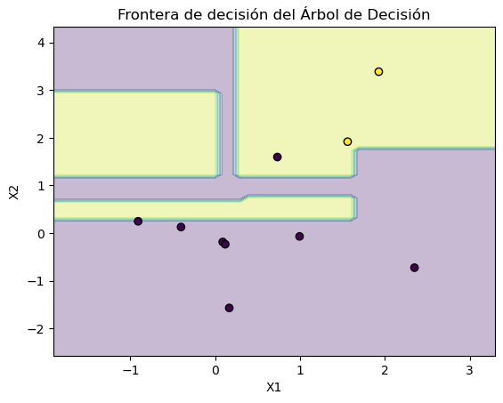

```
Accuracy: 0.9
              precision    recall  f1-score   support

           0       1.00      0.88      0.93         8
           1       0.67      1.00      0.80         2

    accuracy                           0.90        10
   macro avg       0.83      0.94      0.87        10
weighted avg       0.93      0.90      0.91        10
```

```
<sklearn.metrics._plot.confusion_matrix.ConfusionMatrixDisplay at 0x30230b650>
```

```python
#Entrenamiento y prueba
X_train, X_test, Y_train, Y_test = train_test_split(X_50, Y_50, test_size=0.2,random_state=4)

#Árbol de decisión
clf = DecisionTreeClassifier(random_state=42)
clf.fit(X_train, Y_train)

#Predicción sobre conjunto test
Y_pred = clf.predict(X_test)

plot_decision_boundary(clf,X_test, Y_test, "Frontera de decisión del Árbol de Decisión")

#Evaluación
print("Accuracy:", accuracy_score(Y_test, Y_pred))
print(classification_report(Y_test, Y_pred))

#Matriz de confusión
disp = ConfusionMatrixDisplay(confusion_matrix=confusion_matrix(Y_test, Y_pred))
disp.plot()
```

[output not shown]

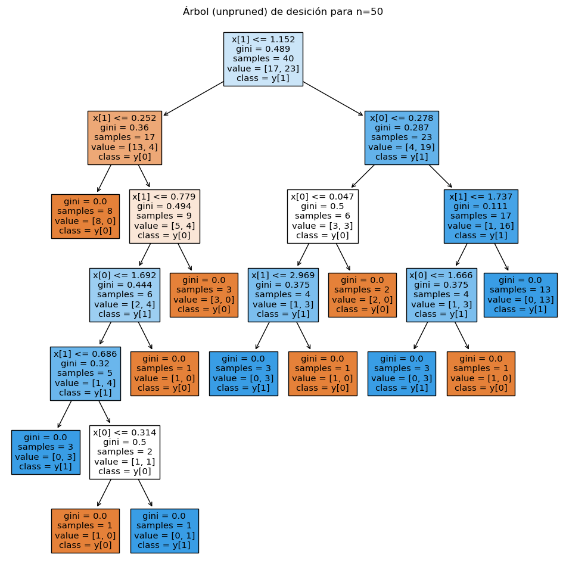

```python
plt.figure(figsize=(12, 12))
tree.plot_tree(clf,class_names=True,filled=True)
plt.title("Árbol (unpruned) de desición para n=50")
plt.show()
```

```python
clf.get_depth()
```

```
6
```

- cross validation

```python
#Entrenamos y validar modelos de árboles de decisión utilizando validación cruzada
#definimos 3 modelos de distintas profundidades
models = {
    'depth_2': DecisionTreeClassifier(max_depth=2, random_state=4),
    'depth_3': DecisionTreeClassifier(max_depth=3, random_state=4),
    'unrestricted': DecisionTreeClassifier(random_state=4)
}

#Realizamos validación cruzada para cada modelo
cv_scores = {}
for name, model in models.items():
    scores = cross_val_score(model, X_train, Y_train, cv=3)
    cv_scores[name] = scores
    #imprimimos el promedio de accuracy del cross-validation
    print(f"Model: {name}, Mean CV Accuracy: {np.mean(scores)}")
```

```
Model: depth_2, Mean CV Accuracy: 0.6758241758241758
Model: depth_3, Mean CV Accuracy: 0.6758241758241758
Model: unrestricted, Mean CV Accuracy: 0.6501831501831502
```

- Best model (CV) vs Optimal Bayesian

```python
#______________MEJOR TREE________________
#Ajustamos el mejor modelo
best_model_name = max(cv_scores, key=lambda name: np.mean(cv_scores[name]))
best_model = models[best_model_name]
best_model.fit(X_train, Y_train)
#Hacemos Predicción sobre el conjunto test
Y_pred = best_model.predict(X_test)
#Imprimimos Evaluación
print("__________Mejor Árbol de Desicion (CV)__________\n")
print("Accuracy:", accuracy_score(Y_test, Y_pred))
print(classification_report(Y_test, Y_pred))

#______________BAYESIANO________________
mu0 = [0, 0]
mu1 = [1, 2]
#Hacemos la predicción con el clasificador Bayesiano
Y_pred_bayes_test = bayesian_classifier(X_test,mu0,mu1,A)
#accuracy bayes
bayes_test_accuracy = accuracy_score(Y_test, Y_pred_bayes_test)
#Imprimimos Evaluación
print("__________Clasficador Bayesiano óptimo__________\n")
print(f"Accuracy: {bayes_test_accuracy}")
print(classification_report(Y_test, Y_pred_bayes_test))
```

```
__________Mejor Árbol de Desicion (CV)__________

Accuracy: 0.9
              precision    recall  f1-score   support

           0       1.00      0.88      0.93         8
           1       0.67      1.00      0.80         2

    accuracy                           0.90        10
   macro avg       0.83      0.94      0.87        10
weighted avg       0.93      0.90      0.91        10

__________Clasficador Bayesiano óptimo__________

Accuracy: 0.9
              precision    recall  f1-score   support

           0       1.00      0.88      0.93         8
           1       0.67      1.00      0.80         2

    accuracy                           0.90        10
   macro avg       0.83      0.94      0.87        10
weighted avg       0.93      0.90      0.91        10
```

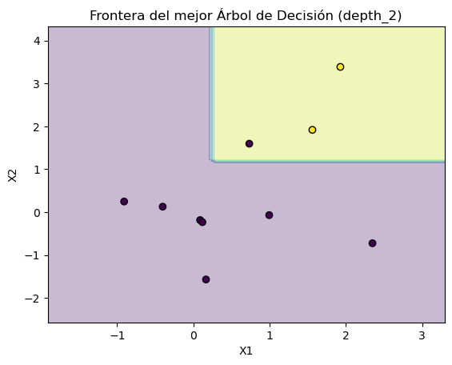

```python
plot_decision_boundary(best_model, X_test, Y_test, f"Frontera del mejor Árbol de Decisión ({best_model_name})")
```

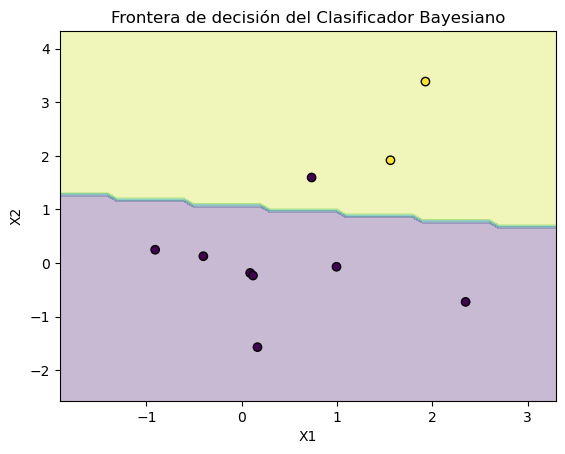

```python
plot_decision_boundary(lambda x: bayesian_classifier(x,mu0,mu1,A), X_test, Y_test, "Frontera de decisión del Clasificador Bayesiano")
```

n=100

- Unpruned Desicion Trees

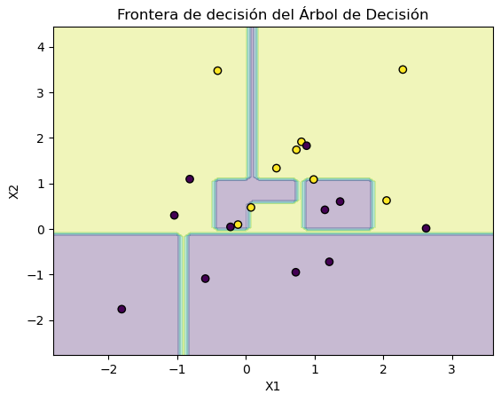

```
Accuracy: 0.7
              precision    recall  f1-score   support

           0       0.78      0.64      0.70        11
           1       0.64      0.78      0.70         9

    accuracy                           0.70        20
   macro avg       0.71      0.71      0.70        20
weighted avg       0.71      0.70      0.70        20
```

```
<sklearn.metrics._plot.confusion_matrix.ConfusionMatrixDisplay at 0x30183c6d0>
```

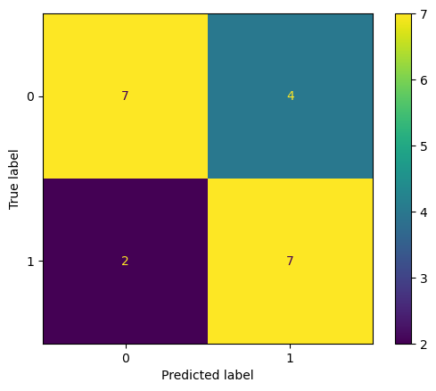

```python
#Entrenamiento y prueba
X_train, X_test, Y_train, Y_test = train_test_split(X_100, Y_100, test_size=0.2,random_state=4)

#Árbol de decisión
clf = DecisionTreeClassifier(random_state=4)
clf.fit(X_train, Y_train)

#Predicción sobre conjunto test
Y_pred = clf.predict(X_test)

plot_decision_boundary(clf,X_test, Y_test, "Frontera de decisión del Árbol de Decisión")

#Evaluación
print("Accuracy:", accuracy_score(Y_test, Y_pred))
print(classification_report(Y_test, Y_pred))

#Matriz de confusión
disp = ConfusionMatrixDisplay(confusion_matrix=confusion_matrix(Y_test, Y_pred))
disp.plot()
```

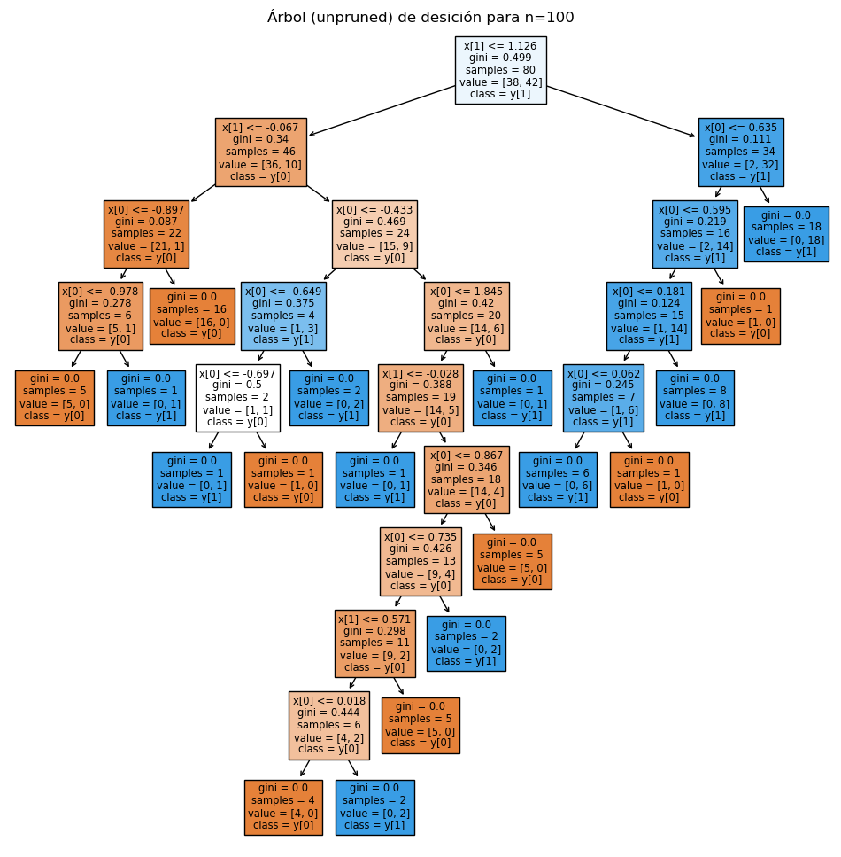

```python
plt.figure(figsize=(12, 12))
tree.plot_tree(clf,class_names=True,filled=True)
plt.title("Árbol (unpruned) de desición para n=100")
plt.show()
```

```python
clf.get_depth()
```

```
9
```

- cross validation

```python
#Entrenamos y validar modelos de árboles de decisión utilizando validación cruzada
#definimos modelos de distintas profundidades
models = {
    'depth_2': DecisionTreeClassifier(max_depth=2, random_state=4),
    'depth_3': DecisionTreeClassifier(max_depth=3, random_state=4),
    'depth_5': DecisionTreeClassifier(max_depth=5, random_state=4),
    'unrestricted': DecisionTreeClassifier(random_state=4)
}

#Realizamos validación cruzada para cada modelo
cv_scores = {}
for name, model in models.items():
    scores = cross_val_score(model, X_train, Y_train, cv=5)
    cv_scores[name] = scores
    #imprimimos el promedio de accuracy del cross-validation
    print(f"Model: {name}, Mean CV Accuracy: {np.mean(scores)}")
```

```
Model: depth_2, Mean CV Accuracy: 0.7625
Model: depth_3, Mean CV Accuracy: 0.8
Model: depth_5, Mean CV Accuracy: 0.7625
Model: unrestricted, Mean CV Accuracy: 0.725
```

- Best model (CV) vs Optimal Bayesian

```python
#______________MEJOR TREE________________
#Ajustamos el mejor modelo
best_model_name = max(cv_scores, key=lambda name: np.mean(cv_scores[name]))
best_model = models[best_model_name]
best_model.fit(X_train, Y_train)
#Hacemos Predicción sobre el conjunto test
Y_pred = best_model.predict(X_test)
#Imprimimos Evaluación
print("__________Mejor Árbol de Desicion (CV)__________\n")
print("Accuracy:", accuracy_score(Y_test, Y_pred))
print(classification_report(Y_test, Y_pred))

#______________BAYESIANO________________
mu0 = [0, 0]
mu1 = [1, 2]
#Hacemos la predicción con el clasificador Bayesiano
Y_pred_bayes_test = bayesian_classifier(X_test,mu0,mu1,A)
#accuracy bayes
bayes_test_accuracy = accuracy_score(Y_test, Y_pred_bayes_test)
#Imprimimos Evaluación
print("__________Clasficador Bayesiano óptimo__________\n")
print(f"Accuracy: {bayes_test_accuracy}")
print(classification_report(Y_test, Y_pred_bayes_test))
```

```
__________Mejor Árbol de Desicion (CV)__________

Accuracy: 0.65
              precision    recall  f1-score   support

           0       0.67      0.73      0.70        11
           1       0.62      0.56      0.59         9

    accuracy                           0.65        20
   macro avg       0.65      0.64      0.64        20
weighted avg       0.65      0.65      0.65        20

__________Clasficador Bayesiano óptimo__________

Accuracy: 0.8
              precision    recall  f1-score   support

           0       0.77      0.91      0.83        11
           1       0.86      0.67      0.75         9

    accuracy                           0.80        20
   macro avg       0.81      0.79      0.79        20
weighted avg       0.81      0.80      0.80        20
```

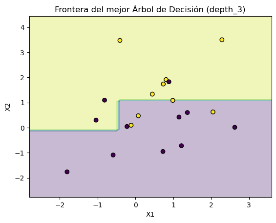

```python
plot_decision_boundary(best_model, X_test, Y_test, f"Frontera del mejor Árbol de Decisión ({best_model_name})")
```

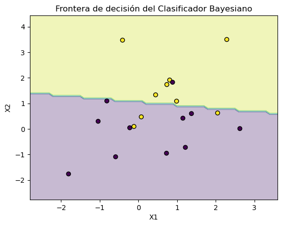

```python
plot_decision_boundary(lambda x: bayesian_classifier(x,mu0,mu1,A), X_test, Y_test, "Frontera de decisión del Clasificador Bayesiano")
```

n=500

- Unpruned Desicion Trees

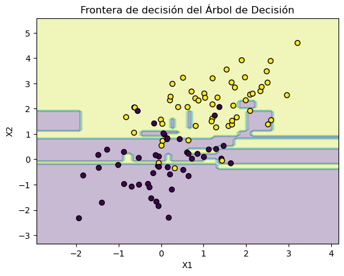

```
Accuracy: 0.84
              precision    recall  f1-score   support

           0       0.82      0.85      0.83        47
           1       0.86      0.83      0.85        53

    accuracy                           0.84       100
   macro avg       0.84      0.84      0.84       100
weighted avg       0.84      0.84      0.84       100
```

```
<sklearn.metrics._plot.confusion_matrix.ConfusionMatrixDisplay at 0x178c00c10>
```

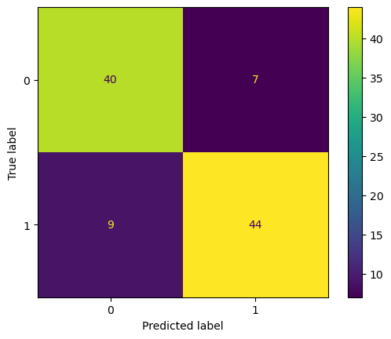

```python
#Entrenamiento y prueba
X_train, X_test, Y_train, Y_test = train_test_split(X_500, Y_500, test_size=0.2,random_state=4)

#Árbol de decisión
clf = DecisionTreeClassifier(random_state=4)
clf.fit(X_train, Y_train)

#Predicción sobre conjunto test
Y_pred = clf.predict(X_test)

plot_decision_boundary(clf,X_test, Y_test, "Frontera de decisión del Árbol de Decisión")

#Evaluación
print("Accuracy:", accuracy_score(Y_test, Y_pred))
print(classification_report(Y_test, Y_pred))

#Matriz de confusión
disp = ConfusionMatrixDisplay(confusion_matrix=confusion_matrix(Y_test, Y_pred))
disp.plot()
```

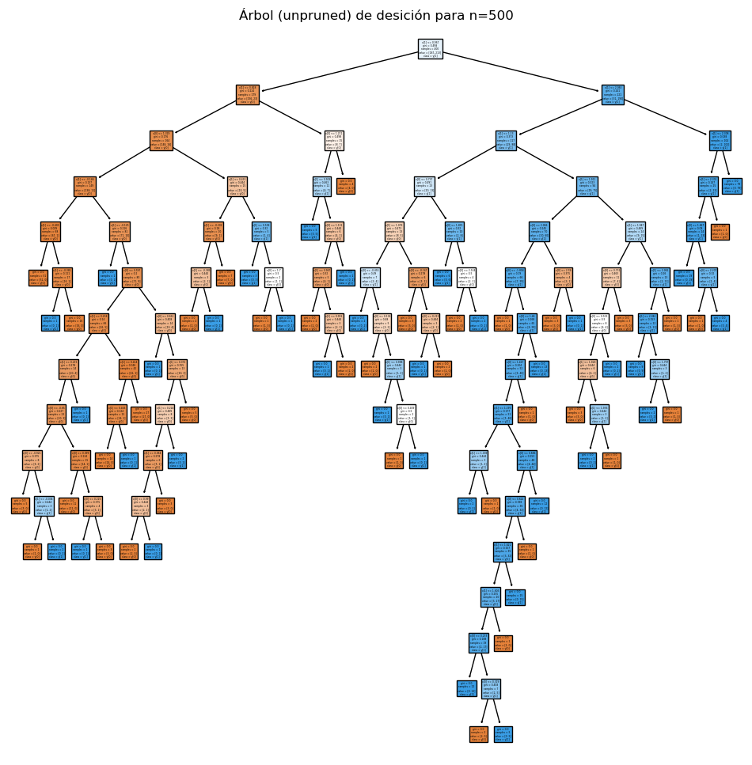

```python
plt.figure(figsize=(12, 12))
tree.plot_tree(clf,class_names=True,filled=True)
plt.title("Árbol (unpruned) de desición para n=500")
plt.show()
```

```python
clf.get_depth()
```

```
15
```

- cross validation

```python
#Entrenamos y validar modelos de árboles de decisión utilizando validación cruzada
#definimos modelos de distintas profundidades
models = {
    'depth_2': DecisionTreeClassifier(max_depth=2, random_state=4),
    'depth_5': DecisionTreeClassifier(max_depth=5, random_state=4),
    'depth_10': DecisionTreeClassifier(max_depth=10, random_state=4),
    'depth_12': DecisionTreeClassifier(max_depth=12, random_state=4),
    'unrestricted': DecisionTreeClassifier(random_state=4)
}

#Realizamos validación cruzada para cada modelo
cv_scores = {}
for name, model in models.items():
    scores = cross_val_score(model, X_train, Y_train, cv=40)
    cv_scores[name] = scores
    #imprimimos el promedio de accuracy del cross-validation
    print(f"Model: {name}, Mean CV Accuracy: {np.mean(scores)}")
```

```
Model: depth_2, Mean CV Accuracy: 0.845
Model: depth_5, Mean CV Accuracy: 0.82
Model: depth_10, Mean CV Accuracy: 0.8125
Model: depth_12, Mean CV Accuracy: 0.7899999999999999
Model: unrestricted, Mean CV Accuracy: 0.7874999999999999
```

- Best model (CV) vs Optimal Bayesian

```python
#______________MEJOR TREE________________
#Ajustamos el mejor modelo
best_model_name = max(cv_scores, key=lambda name: np.mean(cv_scores[name]))
best_model = models[best_model_name]
best_model.fit(X_train, Y_train)
#Hacemos Predicción sobre el conjunto test
Y_pred = best_model.predict(X_test)
#Imprimimos Evaluación
print("__________Mejor Árbol de Desicion (CV)__________\n")
print("Accuracy:", accuracy_score(Y_test, Y_pred))
print(classification_report(Y_test, Y_pred))

#______________BAYESIANO________________
mu0 = [0, 0]
mu1 = [1, 2]
#Hacemos la predicción con el clasificador Bayesiano
Y_pred_bayes_test = bayesian_classifier(X_test,mu0,mu1,A)
#accuracy bayes
bayes_test_accuracy = accuracy_score(Y_test, Y_pred_bayes_test)
#Imprimimos Evaluación
print("__________Clasficador Bayesiano óptimo__________\n")
print(f"Accuracy: {bayes_test_accuracy}")
print(classification_report(Y_test, Y_pred_bayes_test))
```

```
__________Mejor Árbol de Desicion (CV)__________

Accuracy: 0.86
              precision    recall  f1-score   support

           0       0.85      0.85      0.85        47
           1       0.87      0.87      0.87        53

    accuracy                           0.86       100
   macro avg       0.86      0.86      0.86       100
weighted avg       0.86      0.86      0.86       100

__________Clasficador Bayesiano óptimo__________

Accuracy: 0.87
              precision    recall  f1-score   support

           0       0.84      0.89      0.87        47
           1       0.90      0.85      0.87        53

    accuracy                           0.87       100
   macro avg       0.87      0.87      0.87       100
weighted avg       0.87      0.87      0.87       100
```

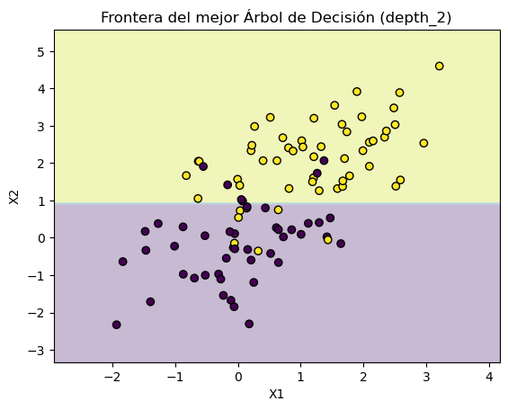

```python
plot_decision_boundary(best_model, X_test, Y_test, f"Frontera del mejor Árbol de Decisión ({best_model_name})")
```

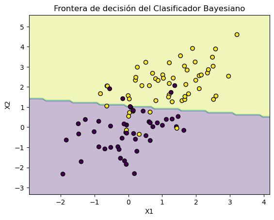

```python
plot_decision_boundary(lambda x: bayesian_classifier(x,mu0,mu1,A), X_test, Y_test, "Frontera de decisión del Clasificador Bayesiano")
```

CONCLUSIONES:

*En los tres casos, el mejor resultado se obtuvo para un árbol podado.

d)

En este inciso para cada $n \in [50,100,500]$:

```
1. Se divide el conjunto total en Train y Test

2. Se ajusta el modelo de regresion lineal SIMPLE (sin interacción)
    (se hace la predicción sobre el conjunto test, el acurracy, el classification_report y la matriz de confusión)

3. A los arreglos X_train y X_test se les agrega una tercera columna donde se almacena el producto $X[0]*X[1]$

4. Se ajusta el modelo de regresion lineal con interacción
    (se hace la predicción sobre el conjunto test, el acurracy, el classification_report y la matriz de confusión)
```

Al final se encuentran las conclusiones

n=50

```python
#conjuntos Entrenamiento y teest
X_train, X_test, Y_train, Y_test = train_test_split(X_50, Y_50, test_size=0.2,random_state=4)

#Ajustamo el modelo de regresión logística sin interacción
log_reg_simple = LogisticRegression()
log_reg_simple.fit(X_train, Y_train)

##Predicción sobre conjunto test
Y_pred_simple = log_reg_simple.predict(X_test)

#Evaluación
accuracy_simple = accuracy_score(Y_test, Y_pred_simple)
print(f"Accuracy: {accuracy_simple}")
print(classification_report(Y_test, Y_pred_simple))

#Matriz de confusión
disp = ConfusionMatrixDisplay(confusion_matrix=confusion_matrix(Y_test, Y_pred_simple))
disp.plot()
```

[output not shown]

```
Accuracy: 0.9
              precision    recall  f1-score   support

           0       1.00      0.88      0.93         8
           1       0.67      1.00      0.80         2

    accuracy                           0.90        10
   macro avg       0.83      0.94      0.87        10
weighted avg       0.93      0.90      0.91        10
```

```
<sklearn.metrics._plot.confusion_matrix.ConfusionMatrixDisplay at 0x179c6b3d0>
```

```python
#Creamos un nuevo arreglo X_train_interaction que cntiene las dos columnas de X_train
#y una nueva columna con el producto de éstas
#y \sim x1+x2+x1*x2
X_train_interaction = np.hstack((X_train, (X_train[:, 0] * X_train[:, 1]).reshape(-1, 1)))
#lo mismo con X_test_interaction
X_test_interaction = np.hstack((X_test, (X_test[:, 0] * X_test[:, 1]).reshape(-1, 1)))
```

```python
#Ajustamos el modelo de regresión logística con términos de interacción
log_reg_interaction = LogisticRegression()
log_reg_interaction.fit(X_train_interaction, Y_train)

#Predicción sobre conjunto test
Y_pred_interaction = log_reg_interaction.predict(X_test_interaction)

#Evaluación
accuracy_interaction = accuracy_score(Y_test, Y_pred_interaction)
print(f"Accuracy: {accuracy_interaction:.4f}")
print(classification_report(Y_test, Y_pred_interaction))

#Matriz de confusión
disp = ConfusionMatrixDisplay(confusion_matrix=confusion_matrix(Y_test, Y_pred_interaction))
disp.plot()
```

[output not shown]

```
Accuracy: 0.9000
              precision    recall  f1-score   support

           0       1.00      0.88      0.93         8
           1       0.67      1.00      0.80         2

    accuracy                           0.90        10
   macro avg       0.83      0.94      0.87        10
weighted avg       0.93      0.90      0.91        10
```

```
<sklearn.metrics._plot.confusion_matrix.ConfusionMatrixDisplay at 0x1370b8a90>
```

n=100

```
Accuracy: 0.75
              precision    recall  f1-score   support

           0       0.75      0.82      0.78        11
           1       0.75      0.67      0.71         9

    accuracy                           0.75        20
   macro avg       0.75      0.74      0.74        20
weighted avg       0.75      0.75      0.75        20
```

```
<sklearn.metrics._plot.confusion_matrix.ConfusionMatrixDisplay at 0x178a9a650>
```

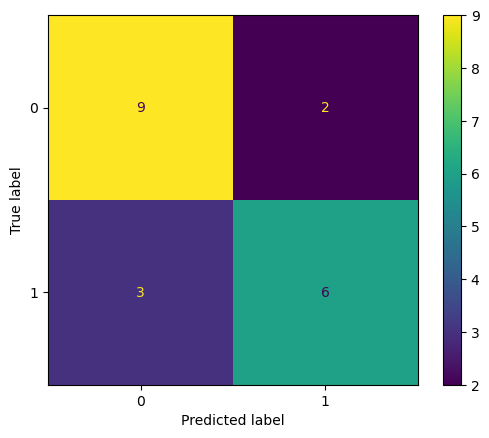

```python
#conjuntos Entrenamiento y teest
X_train, X_test, Y_train, Y_test = train_test_split(X_100, Y_100, test_size=0.2,random_state=4)

#Ajustamos el modelo de regresión logística sin interacción
log_reg_simple = LogisticRegression()
log_reg_simple.fit(X_train, Y_train)

##Predicción sobre conjunto test
Y_pred_simple = log_reg_simple.predict(X_test)

#Evaluación
accuracy_simple = accuracy_score(Y_test, Y_pred_simple)
print(f"Accuracy: {accuracy_simple}")
print(classification_report(Y_test, Y_pred_simple))

#Matriz de confusión
disp = ConfusionMatrixDisplay(confusion_matrix=confusion_matrix(Y_test, Y_pred_simple))
disp.plot()
```

```python
#Creamos un nuevo arreglo X_train_interaction que cntiene las dos columnas de X_train
#y una nueva columna con el producto de éstas
#y \sim x1+x2+x1*x2
X_train_interaction = np.hstack((X_train, (X_train[:, 0] * X_train[:, 1]).reshape(-1, 1)))
#lo mismo con X_test_interaction
X_test_interaction = np.hstack((X_test, (X_test[:, 0] * X_test[:, 1]).reshape(-1, 1)))
```

```
Accuracy: 0.7500
              precision    recall  f1-score   support

           0       0.75      0.82      0.78        11
           1       0.75      0.67      0.71         9

    accuracy                           0.75        20
   macro avg       0.75      0.74      0.74        20
weighted avg       0.75      0.75      0.75        20
```

```
<sklearn.metrics._plot.confusion_matrix.ConfusionMatrixDisplay at 0x168cec290>
```

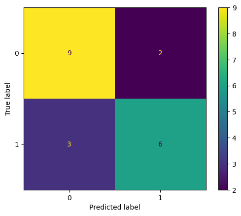

```python
#Ajustamos el modelo de regresión logística con términos de interacción
log_reg_interaction = LogisticRegression()
log_reg_interaction.fit(X_train_interaction, Y_train)

#Predicción sobre conjunto test
Y_pred_interaction = log_reg_interaction.predict(X_test_interaction)

#Evaluación
accuracy_interaction = accuracy_score(Y_test, Y_pred_interaction)
print(f"Accuracy: {accuracy_interaction:.4f}")
print(classification_report(Y_test, Y_pred_interaction))

#Matriz de confusión
disp = ConfusionMatrixDisplay(confusion_matrix=confusion_matrix(Y_test, Y_pred_interaction))
disp.plot()
```

n=500

```
Accuracy: 0.85
              precision    recall  f1-score   support

           0       0.89      0.80      0.85        51
           1       0.81      0.90      0.85        49

    accuracy                           0.85       100
   macro avg       0.85      0.85      0.85       100
weighted avg       0.85      0.85      0.85       100
```

```
<sklearn.metrics._plot.confusion_matrix.ConfusionMatrixDisplay at 0x179ed9f10>
```

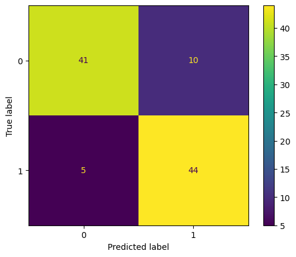

```python
#conjuntos Entrenamiento y teest
X_train, X_test, Y_train, Y_test = train_test_split(X_500, Y_500, test_size=0.2,random_state=41)

#Ajustamos el modelo de regresión logística sin interacción
log_reg_simple = LogisticRegression()
log_reg_simple.fit(X_train, Y_train)

##Predicción sobre conjunto test
Y_pred_simple = log_reg_simple.predict(X_test)

#Evaluación
accuracy_simple = accuracy_score(Y_test, Y_pred_simple)
print(f"Accuracy: {accuracy_simple}")
print(classification_report(Y_test, Y_pred_simple))

#Matriz de confusión
disp = ConfusionMatrixDisplay(confusion_matrix=confusion_matrix(Y_test, Y_pred_simple))
disp.plot()
```

```python
#Creamos un nuevo arreglo X_train_interaction que cntiene las dos columnas de X_train
#y una nueva columna con el producto de éstas
#y \sim x1+x2+x1*x2
X_train_interaction = np.hstack((X_train, (X_train[:, 0] * X_train[:, 1]).reshape(-1, 1)))
#lo mismo con X_test_interaction
X_test_interaction = np.hstack((X_test, (X_test[:, 0] * X_test[:, 1]).reshape(-1, 1)))
```

```
Accuracy: 0.8500
              precision    recall  f1-score   support

           0       0.89      0.80      0.85        51
           1       0.81      0.90      0.85        49

    accuracy                           0.85       100
   macro avg       0.85      0.85      0.85       100
weighted avg       0.85      0.85      0.85       100
```

```
<sklearn.metrics._plot.confusion_matrix.ConfusionMatrixDisplay at 0x168f93650>
```

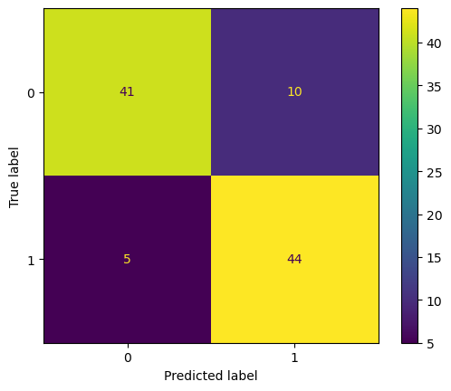

```python
#Ajustamos el modelo de regresión logística con términos de interacción
log_reg_interaction = LogisticRegression()
log_reg_interaction.fit(X_train_interaction, Y_train)

#Predicción sobre conjunto test
Y_pred_interaction = log_reg_interaction.predict(X_test_interaction)

#Evaluación
accuracy_interaction = accuracy_score(Y_test, Y_pred_interaction)
print(f"Accuracy: {accuracy_interaction:.4f}")
print(classification_report(Y_test, Y_pred_interaction))

#Matriz de confusión
disp = ConfusionMatrixDisplay(confusion_matrix=confusion_matrix(Y_test, Y_pred_interaction))
disp.plot()
```

n=50 Reg Simple y Reg con Interacción tuvieron accuracy y precisión idéntica.

e)

En este inciso para cada $n \in [50,100,500]$:

```
1. Se divide el conjunto total en Train y Test

2. Se ajusta el modelo SVM con kernel lineal
    (se hace la predicción sobre el conjunto test, el acurracy, el classification_report y la matriz de confusión)

3. Se ajusta el modelo SVM con kernel base radial
    (se hace la predicción sobre el conjunto test, el acurracy, el classification_report y la matriz de confusión)
```

Al final se encuentran las conclusiones

n=50

```python
#entrenamiento y test
X_train, X_test, Y_train, Y_test = train_test_split(X_50,Y_50, test_size=0.2, random_state=4)

#Ajstamos el modelo SVM con kernel lineal
svm_linear = SVC(kernel='linear')
svm_linear.fit(X_train, Y_train)

#Predicción sobre conjunto test
Y_pred_linear = svm_linear.predict(X_test)

#Evaluación
accuracy_linear = accuracy_score(Y_test, Y_pred_linear)
print(f"Accuracy: {accuracy_linear}")
print(classification_report(Y_test, Y_pred_linear))

#Matriz de confusión
disp = ConfusionMatrixDisplay(confusion_matrix=confusion_matrix(Y_test, Y_pred_linear))
disp.plot()
```

[output not shown]

```
Accuracy: 0.9
              precision    recall  f1-score   support

           0       1.00      0.88      0.93         8
           1       0.67      1.00      0.80         2

    accuracy                           0.90        10
   macro avg       0.83      0.94      0.87        10
weighted avg       0.93      0.90      0.91        10
```

```
<sklearn.metrics._plot.confusion_matrix.ConfusionMatrixDisplay at 0x30249f550>
```

```python
#Ajustamos el modelo SVM con kernel RBF
svm_rbf = SVC(kernel='rbf')
svm_rbf.fit(X_train, Y_train)

#Predicción sobre conjunto test
Y_pred_rbf = svm_rbf.predict(X_test)

#Evaluación
accuracy_rbf = accuracy_score(Y_test, Y_pred_rbf)
print(f"Accuracy: {accuracy_rbf}")
print(classification_report(Y_test, Y_pred_rbf))

#Matriz de confusión
disp = ConfusionMatrixDisplay(confusion_matrix=confusion_matrix(Y_test, Y_pred_rbf))
disp.plot()
```

[output not shown]

```
Accuracy: 0.9
              precision    recall  f1-score   support

           0       1.00      0.88      0.93         8
           1       0.67      1.00      0.80         2

    accuracy                           0.90        10
   macro avg       0.83      0.94      0.87        10
weighted avg       0.93      0.90      0.91        10
```

```
<sklearn.metrics._plot.confusion_matrix.ConfusionMatrixDisplay at 0x3049d2310>
```

n=100

```
Accuracy: 0.7000
              precision    recall  f1-score   support

           0       0.69      0.82      0.75        11
           1       0.71      0.56      0.63         9

    accuracy                           0.70        20
   macro avg       0.70      0.69      0.69        20
weighted avg       0.70      0.70      0.69        20
```

```
<sklearn.metrics._plot.confusion_matrix.ConfusionMatrixDisplay at 0x304ba0450>
```

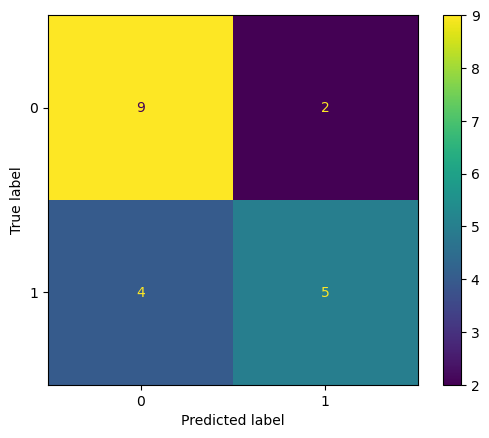

```python
#entrenamiento y test
X_train, X_test, Y_train, Y_test = train_test_split(X_100,Y_100, test_size=0.2, random_state=41)

#Ajstamos el modelo SVM con kernel lineal
svm_linear = SVC(kernel='linear')
svm_linear.fit(X_train, Y_train)

# Predicción sobre conjunto test
Y_pred_linear = svm_linear.predict(X_test)

#Evaluación
accuracy_linear = accuracy_score(Y_test, Y_pred_linear)
print(f"Accuracy: {accuracy_linear:.4f}")
print(classification_report(Y_test, Y_pred_linear))

#Matriz de confusión
disp = ConfusionMatrixDisplay(confusion_matrix=confusion_matrix(Y_test, Y_pred_linear))
disp.plot()
```

```
Accuracy: 0.7000
              precision    recall  f1-score   support

           0       0.69      0.82      0.75        11
           1       0.71      0.56      0.63         9

    accuracy                           0.70        20
   macro avg       0.70      0.69      0.69        20
weighted avg       0.70      0.70      0.69        20
```

```
<sklearn.metrics._plot.confusion_matrix.ConfusionMatrixDisplay at 0x304af4d10>
```

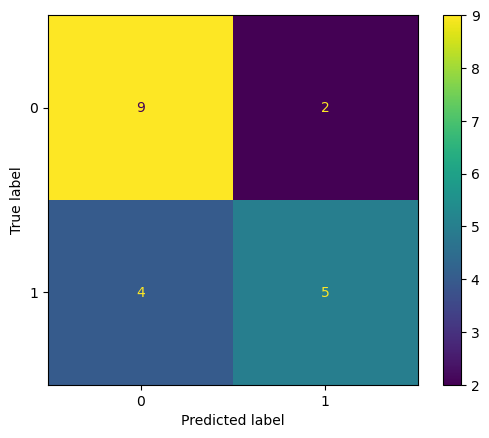

```python
#Ajustaos el modelo SVM con kernel RBF
svm_rbf = SVC(kernel='rbf')
svm_rbf.fit(X_train, Y_train)

# Predicción sobre conjunto test
Y_pred_rbf = svm_rbf.predict(X_test)

#Evaluación
accuracy_rbf = accuracy_score(Y_test, Y_pred_rbf)
print(f"Accuracy: {accuracy_rbf:.4f}")
print(classification_report(Y_test, Y_pred_rbf))

#Matriz de confusión
disp = ConfusionMatrixDisplay(confusion_matrix=confusion_matrix(Y_test, Y_pred_rbf))
disp.plot()
```

n=500

```
Accuracy: 0.8400
              precision    recall  f1-score   support

           0       0.87      0.80      0.84        51
           1       0.81      0.88      0.84        49

    accuracy                           0.84       100
   macro avg       0.84      0.84      0.84       100
weighted avg       0.84      0.84      0.84       100
```

```
<sklearn.metrics._plot.confusion_matrix.ConfusionMatrixDisplay at 0x3049f5750>
```

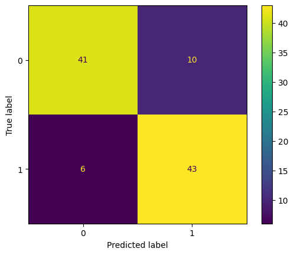

```python
#entrenamiento y test
X_train, X_test, Y_train, Y_test = train_test_split(X_500,Y_500, test_size=0.2, random_state=41)

#Ajstamos el modelo SVM con kernel lineal
svm_linear = SVC(kernel='linear')
svm_linear.fit(X_train, Y_train)

# Predicción sobre conjunto test
Y_pred_linear = svm_linear.predict(X_test)

#Evaluación
accuracy_linear = accuracy_score(Y_test, Y_pred_linear)
print(f"Accuracy: {accuracy_linear:.4f}")
print(classification_report(Y_test, Y_pred_linear))

#Matriz de confusión
disp = ConfusionMatrixDisplay(confusion_matrix=confusion_matrix(Y_test, Y_pred_linear))
disp.plot()
```

```
Accuracy: 0.84
              precision    recall  f1-score   support

           0       0.87      0.80      0.84        51
           1       0.81      0.88      0.84        49

    accuracy                           0.84       100
   macro avg       0.84      0.84      0.84       100
weighted avg       0.84      0.84      0.84       100
```

```
<sklearn.metrics._plot.confusion_matrix.ConfusionMatrixDisplay at 0x302559290>
```

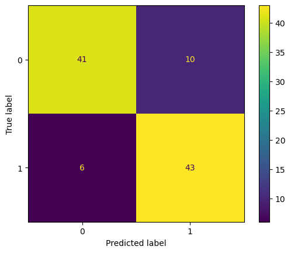

```python
#Ajustamos el modelo SVM con kernel RBF
svm_rbf = SVC(kernel='rbf')
svm_rbf.fit(X_train, Y_train)

#Predicción sobre conjunto test
Y_pred_rbf = svm_rbf.predict(X_test)

#Evaluación
accuracy_rbf = accuracy_score(Y_test, Y_pred_rbf)
print(f"Accuracy: {accuracy_rbf}")
print(classification_report(Y_test, Y_pred_rbf))

#Matriz de confusión
disp = ConfusionMatrixDisplay(confusion_matrix=confusion_matrix(Y_test, Y_pred_linear))
disp.plot()
```

n=50

[output not shown]

n=100

[output not shown]

n=500

[output not shown]

$\color{lightblue}{Ejericicio \space 3}$

```python
from sklearn.preprocessing import LabelEncoder
columnas=["Class","age","menopause","tumor_size","inv_nodes","node_caps","deg_malig","breast","breast_quad","irradiat"]

df = pd.read_csv("breast-cancer.data", header=None,names=columnas)

#Modificamos la columna 'Class' para que las etiquetas sean 0 y 1
df['Class'] = df['Class'].map({'no-recurrence-events': 0, 'recurrence-events': 1})

#Reemplazamos '?' con NaN
df.replace('?', np.nan, inplace=True)

#Eliminamos las filas que contienen NaN
df.dropna(inplace=True)

#Inicializamos el LabelEncoder para cambiar las categorias de cada variable por numeros
le = LabelEncoder()

#Convertimos las columnas categóricas
categorical_columns = ["age", "menopause", "tumor_size", "inv_nodes", "node_caps", "breast", "breast_quad", "irradiat"]

for col in categorical_columns:
    df[col] = le.fit_transform(df[col])
```

```python
df
```

|  | Class | age | menopause | tumor_size | inv_nodes | node_caps | deg_malig | breast | breast_quad | irradiat |
| --- | --- | --- | --- | --- | --- | --- | --- | --- | --- | --- |
| 0 | 0 | 1 | 2 | 5 | 0 | 0 | 3 | 0 | 1 | 0 |
| 1 | 0 | 2 | 2 | 3 | 0 | 0 | 2 | 1 | 4 | 0 |
| 2 | 0 | 2 | 2 | 3 | 0 | 0 | 2 | 0 | 1 | 0 |
| 3 | 0 | 4 | 0 | 2 | 0 | 0 | 2 | 1 | 2 | 0 |
| 4 | 0 | 2 | 2 | 0 | 0 | 0 | 2 | 1 | 3 | 0 |
| ... | ... | ... | ... | ... | ... | ... | ... | ... | ... | ... |
| 281 | 1 | 1 | 2 | 5 | 0 | 0 | 2 | 0 | 2 | 0 |
| 282 | 1 | 1 | 2 | 3 | 0 | 0 | 3 | 0 | 2 | 1 |
| 283 | 1 | 4 | 0 | 3 | 0 | 0 | 1 | 1 | 2 | 0 |
| 284 | 1 | 2 | 0 | 5 | 4 | 0 | 3 | 0 | 1 | 0 |
| 285 | 1 | 3 | 0 | 5 | 4 | 0 | 3 | 0 | 1 | 0 |

277 rows × 10 columns

```python
# Separar las características y la variable objetivo
X = df.drop('Class', axis=1)
Y = df['Class']
```

```python
#Entrenamiento y prueba
X_train, X_test, Y_train, Y_test = train_test_split(X, Y, test_size=0.3)
```

Árbol

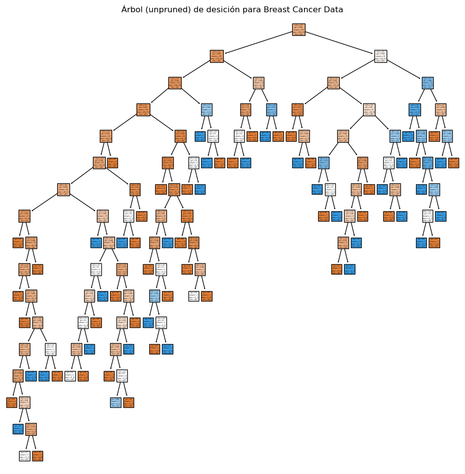

```python
#Árbol de decisión
# Crear y ajustar el modelo de árbol de decisión
clf = DecisionTreeClassifier(random_state=40)
clf.fit(X_train, Y_train)

plt.figure(figsize=(12, 12))
tree.plot_tree(clf,class_names=True,filled=True)
plt.title("Árbol (unpruned) de desición para Breast Cancer Data")
plt.show()
```

```python
clf.get_depth()
```

```
16
```

```python
#Entrenamos y validar modelos de árboles de decisión utilizando validación cruzada
#definimos modelos de distintas profundidades
models = {
    'depth_2': DecisionTreeClassifier(max_depth=2,random_state=40),
    'depth_3': DecisionTreeClassifier(max_depth=3, random_state=40),
    'depth_5': DecisionTreeClassifier(max_depth=5, random_state=40),
    'depth_7': DecisionTreeClassifier(max_depth=7, random_state=40),
    'depth_10': DecisionTreeClassifier(max_depth=10, random_state=40),
    'unrestricted': DecisionTreeClassifier(random_state=40)
}

#Realizamos validación cruzada para cada modelo
cv_scores = {}
for name, model in models.items():
    scores = cross_val_score(model, X_train, Y_train, cv=16)
    cv_scores[name] = scores
    #imprimimos el promedio de accuracy del cross-validation
    print(f"Model: {name}, Mean CV Accuracy: {np.mean(scores)}")



#______________MEJOR TREE________________#
#Ajustamos el mejor modelo
best_model_name = max(cv_scores, key=lambda name: np.mean(cv_scores[name]))
best_model = models[best_model_name]
best_model.fit(X_train, Y_train)
#Hacemos Predicción sobre el conjunto test
Y_pred_tree = best_model.predict(X_test)
```

```
Model: depth_2, Mean CV Accuracy: 0.7776442307692307
Model: depth_3, Mean CV Accuracy: 0.7415865384615384
Model: depth_5, Mean CV Accuracy: 0.7051282051282051
Model: depth_7, Mean CV Accuracy: 0.6634615384615384
Model: depth_10, Mean CV Accuracy: 0.6486378205128205
Model: unrestricted, Mean CV Accuracy: 0.6069711538461539
```

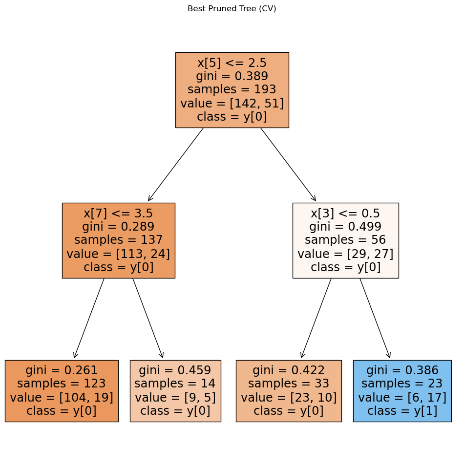

```python
plt.figure(figsize=(12, 12))
tree.plot_tree(best_model,class_names=True,filled=True)
plt.title("Best Pruned Tree (CV)")
plt.show()
```

RL

```python
import statsmodels.api as sm

#Ajustamos un modelo de regresión logística utilizando
#statsmodels para ver el resumen de éste y evaluar
#qué variables vale la penatomar en cuenta y cuales no en función del p-value

log_reg = sm.Logit(Y_train, X_train).fit()
print(log_reg.summary())
```

```
Optimization terminated successfully.
         Current function value: 0.520217
         Iterations 6
                           Logit Regression Results
==============================================================================
Dep. Variable:                  Class   No. Observations:                  193
Model:                          Logit   Df Residuals:                      184
Method:                           MLE   Df Model:                            8
Date:                Sun, 19 May 2024   Pseudo R-squ.:                 0.09912
Time:                        17:33:54   Log-Likelihood:                -100.40
converged:                       True   LL-Null:                       -111.45
Covariance Type:            nonrobust   LLR p-value:                  0.004745
===============================================================================
                  coef    std err          z      P>|z|      [0.025      0.975]
-------------------------------------------------------------------------------
age            -0.6263      0.156     -4.025      0.000      -0.931      -0.321
menopause      -0.5336      0.183     -2.921      0.003      -0.892      -0.175
tumor_size     -0.0328      0.088     -0.371      0.710      -0.206       0.140
inv_nodes       0.1447      0.109      1.323      0.186      -0.070       0.359
node_caps       0.1483      0.525      0.282      0.778      -0.881       1.177
deg_malig       0.3757      0.222      1.696      0.090      -0.059       0.810
breast         -0.1233      0.360     -0.343      0.732      -0.829       0.582
breast_quad     0.1014      0.167      0.606      0.544      -0.226       0.429
irradiat        0.7065      0.411      1.718      0.086      -0.100       1.513
===============================================================================
```